# data_networks

Shannon Dickson

April 11 2023

# Setting up the data

Table 1: Information on how variables are coded

| Variable | Key |
| --- | --- |
| Absolute Relative Bias | Numerical |
| Nonresponse Rate | Numerical |
| Year | N/A |
| Mode | 0 = Paper; 1 = F2F; 2 = Mail; 3 = Telephone; 4 = Web |
| Question Type | 0 = Demographic; 1 = Observable; 2 = Unobservable |
| Reminder | 0 = No; 1 = Yes; 2 = Undetermined |
| Topic | 0 = Other; 1 = Health |
| Population | 0 = No; 1 = Yes |
| Saliency | 0 = No; 1 = Yes |
| Incentives | 0 = No; 1 = Yes |
| Sponsorship | 0 = No; 1 = Yes |

Table 2: Missingness

| ID | Article | StatsID | Author | Year | DataCollDays | MaxNCAttempts | LenghthMin | NQuestions | Prenotification | Sponsorship | Incentiveamount | Reminder | Nreminder | ModeB | Topic | Incentives | Qtype | PopType | StatsType | StatsRelevance | SSizeRBias | SSizeRR | Source | RR | MN | AbsRelbias | Truth | Respondents | Nonrespondents | … |
| --- | --- | --- | --- | --- | --- | --- | --- | --- | --- | --- | --- | --- | --- | --- | --- | --- | --- | --- | --- | --- | --- | --- | --- | --- | --- | --- | --- | --- | --- | --- |
| 0 | 0 | 0 | 0 | 0 | 150 | 229 | 292 | 187 | 1524 | 52 | 2664 | 104 | 1403 | 229 | 12 | 115 | 6 | 48 | 0 | 0 | 0 | 0 | 28 | 5 | 5 | 0 | 0 | 0 | 3 | … |

```r
# Make type and level labels
# type_all and level_all include the mode, to be used on data_net
type_all   <- c("g", "g", "g", "c", "c", "c", "c", "c", "c", "c", "c")
levels_all <- c(1, 1, 1, 2, 2, 3, 2, 2, 2, 3, 5)

# type and levels do not include mode are for the split data
type   <- c("g", "g", "g", "c", "c", "c", "c", "c", "c", "c")
levels <- c(1, 1, 1, 2, 2, 3, 2, 2, 2, 3)

# Make a list of the data sets
# all data
data_net_list <- list(data = data_net, type = type_all, level = levels_all, colnames = colnames(data_net))
# data split by modes
f2f_net_list  <- list(data = f2f_net,  type = type, level = levels, colnames = colnames(f2f_net))
web_net_list  <- list(data = web_net,  type = type, level = levels, colnames = colnames(web_net))
mail_net_list <- list(data = mail_net, type = type, level = levels, colnames = colnames(mail_net))
tel_net_list  <- list(data = tel_net,  type = type, level = levels, colnames = colnames(tel_net))

# checks
length(type_all)
length(levels_all)
length(data_net)

length(f2f_net)
length(levels)
length(type)
```

# Moderated MGM

Here I make a moderated MGM (for interest), which is in theory equivalent to partitioning the data on mode.

```
## Note that the sign of parameter estimates is stored separately; see ?mgm
```

# MGM: All Modes

```
## Note that the sign of parameter estimates is stored separately; see ?mgm
```

```
##              Variable    R2   nCC
## 1          AbsRelbias 0.062    NA
## 2                  MN 0.322    NA
## 3                Year 0.481    NA
## 4            Saliency    NA 0.479
## 5        Incentivised    NA 0.391
## 6            Reminder    NA 0.389
## 7         Sponsorship    NA 0.109
## 8        Topic_Health    NA 0.569
## 9  special_population    NA 0.440
## 10              Qtype    NA 0.240
## 11               Mode    NA 0.372
```

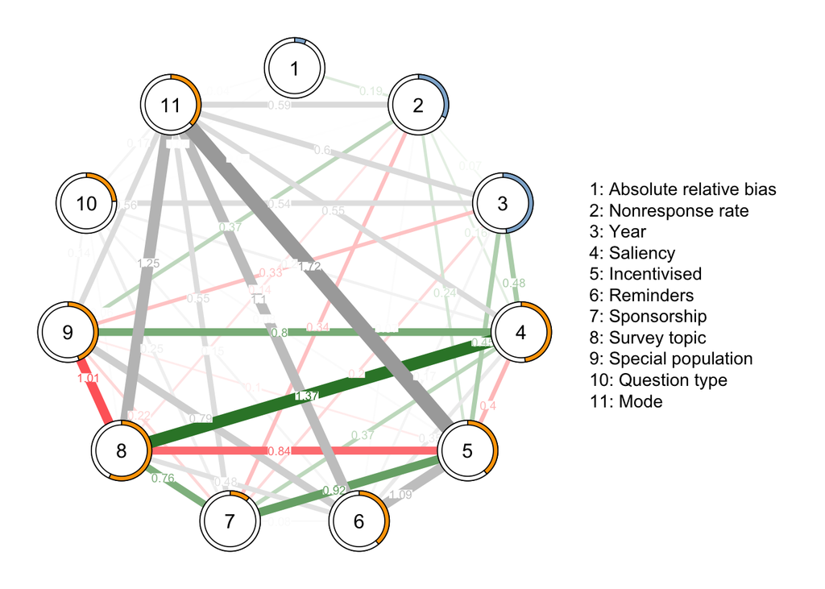

# MGM: F2F

```
## Note that the sign of parameter estimates is stored separately; see ?mgm
```

```
##              Variable    R2   nCC
## 1          AbsRelbias 0.136    NA
## 2                  MN 0.631    NA
## 3                Year 0.869    NA
## 4            Saliency    NA 1.000
## 5        Incentivised    NA 1.000
## 6            Reminder    NA 1.000
## 7         Sponsorship    NA 1.000
## 8        Topic_Health    NA 0.703
## 9  special_population    NA 1.000
## 10              Qtype    NA 0.522
```

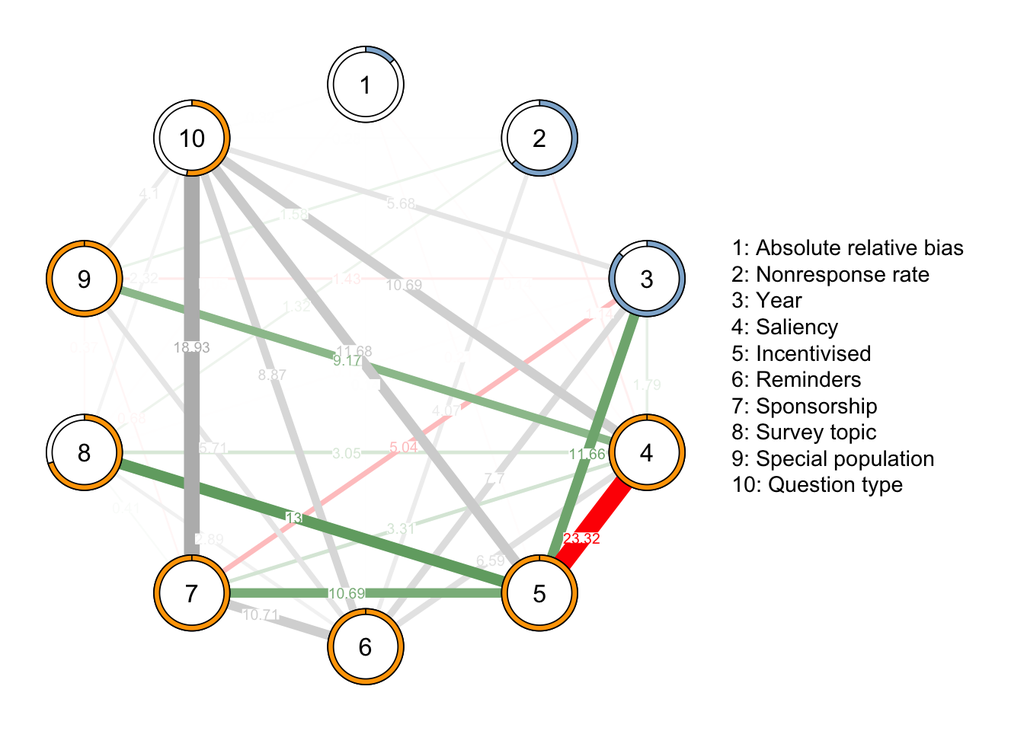

```
## Note that the sign of parameter estimates is stored separately; see ?mgm
```

```
##              Variable    R2   nCC
## 1          AbsRelbias 0.253    NA
## 2                  MN 0.437    NA
## 3                Year 0.000    NA
## 4            Saliency    NA 0.536
## 5        Incentivised    NA 1.000
## 6            Reminder    NA 0.634
## 7         Sponsorship    NA 0.509
## 8        Topic_Health    NA 0.896
## 9  special_population    NA 0.887
## 10              Qtype    NA 0.602
```

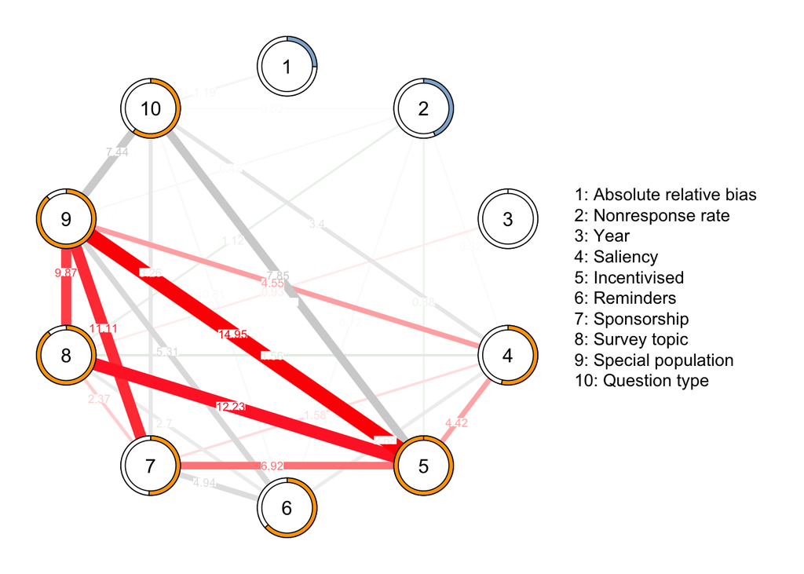

```
## Note that the sign of parameter estimates is stored separately; see ?mgm
```

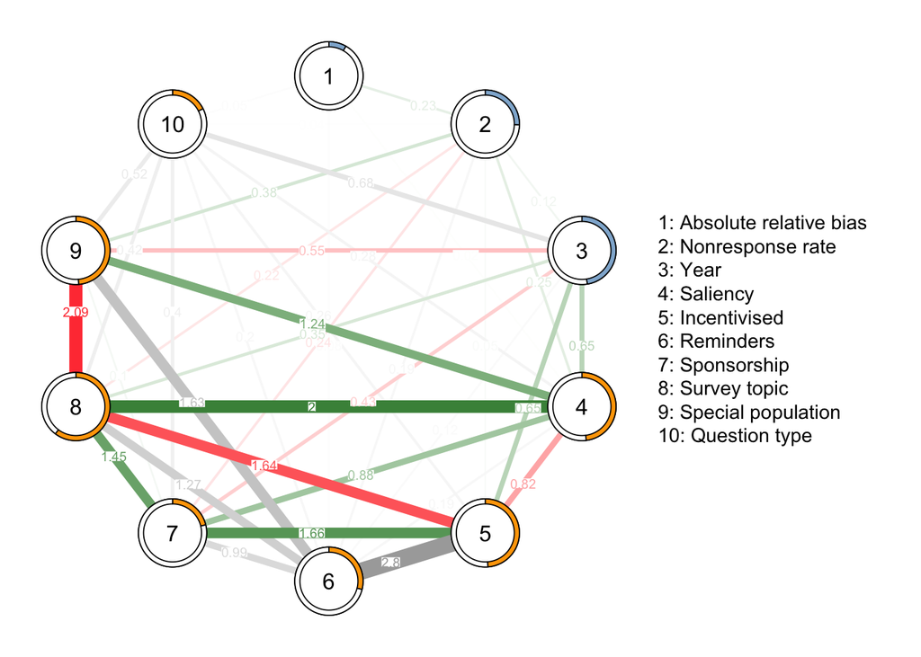

```r
set.seed(123)

mgm_tel <- mgm(data       = as.matrix(tel_net_list$data),
               type       = tel_net_list$type,
               level      = tel_net_list$levels,
               k          = 2,
               lambdaSel  = 'EBIC',
               lambdaGam  = 0.25,
               ruleReg    = "OR",
               binarySign = TRUE,
               scale      = TRUE,
               pbar       = FALSE)
```

```
## Note that the sign of parameter estimates is stored separately; see ?mgm
```

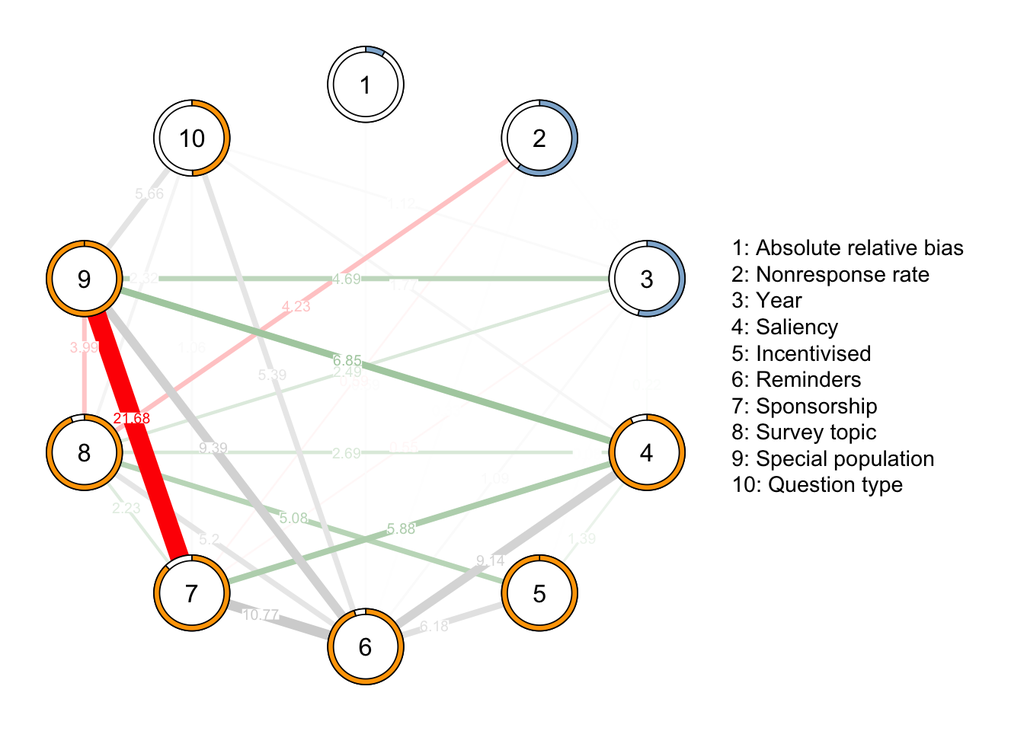

```r
# Predictability of nodes
mgm_predict_tel <- predict(object   = mgm_tel,
                           data     = tel_net_list$data,
                           errorCat = 'nCC',
                           errorCon = 'R2')

errors <- list()
for(i in 1:3)  errors[[i]] <- mgm_predict_tel$errors[i,2]
for(i in 4:10) errors[[i]] <- mgm_predict_tel$errors[i,3]

colors <- list()
for(i in 1:3)  colors[[i]] <- "#90B4D4"
for(i in 4:10) colors[[i]] <- c("#FFA500", "#FF4300")

qgraph(input       = mgm_tel$pairwise$wadj,
       layout      = 'circle',
       edge.color  = mgm_tel$pairwise$edgecolor,
       nodeNames   = nice_colnames[1:10],
       edge.labels = TRUE, edge.label.cex = 0.7, edge.label.bg = TRUE,
       legend.cex  = .45,
       pie        = errors, # provide errors as input
       pieColor   = colors)
```

```r
       #filetype    = "png",
       #filename    = "img/mgm_tel_preds",
       #bg          = "transparent")
```

## Interactions

### All modes

```r
# Interactions - whole network
## Bias (1) and NR (2)
showInteraction(object = mgm_all, int = c(1, 2))$parameters
```

```
## $Predict_1
##           2
## 1 0.1890885
##
## $Predict_2
##           1
## 2 0.1949534
```

```r
## Bias (1) and question type (10)
showInteraction(object = mgm_all, int = c(1, 10))$parameters
```

```
## $Predict_1
##   10.0 10.1        10.2
## 1   NA    0 -0.04381634
##
## $Predict_10
##               1
## 10.0  0.0000000
## 10.1  0.0000000
## 10.2 -0.1507216
```

```r
## Bias (1) mode (11)
showInteraction(object = mgm_all, int = c(1, 11))$parameters
```

```
## $Predict_1
##   11.0 11.1        11.2 11.3 11.4
## 1   NA    0 -0.04332716    0    0
##
## $Predict_11
##               1
## 11.0  0.0000000
## 11.1  0.0000000
## 11.2 -0.1083323
## 11.3  0.2053688
## 11.4  0.0000000
```

```r
## Modes (11) and NR (2)
showInteraction(object = mgm_all, int = c(2, 11))$parameters
```

```
## $Predict_2
##   11.0      11.1      11.2       11.3 11.4
## 2   NA -1.228494 -0.341268 -0.4651466    0
##
## $Predict_11
##               2
## 11.0  0.7701470
## 11.1 -1.8602613
## 11.2  0.0000000
## 11.3 -0.2580896
## 11.4  0.5156340
```

```r
## Modes (11) and Year (3)
showInteraction(object = mgm_all, int = c(11, 3))$parameters
```

```
## $Predict_3
##   11.0       11.1       11.2       11.3      11.4
## 3   NA -0.5931592 -0.3590643 -0.5896506 0.5752132
##
## $Predict_11
##               3
## 11.0  0.5673212
## 11.1 -0.6515406
## 11.2  0.0000000
## 11.3 -0.3134684
## 11.4  1.8642066
```

```r
## Modes (11) and Saliency (4)
showInteraction(object = mgm_all, int = c(11, 4))$parameters
```

```
## $Predict_4
##     11.0       11.1       11.2 11.3      11.4
## 4.0   NA -0.1043463  0.2131088    0  1.702102
## 4.1   NA  0.1043463 -0.2131088    0 -1.702102
##
## $Predict_11
##      4.0        4.1
## 11.0  NA  0.0000000
## 11.1  NA  0.7021697
## 11.2  NA  0.0000000
## 11.3  NA  0.1772418
## 11.4  NA -2.1291649
```

```r
## Modes (11) and Incentive (5)
showInteraction(object = mgm_all, int = c(11, 5))$parameters
```

```
## $Predict_5
##     11.0      11.1      11.2      11.3 11.4
## 5.0   NA -2.507526 -1.536595 -1.292498    0
## 5.1   NA  2.507526  1.536595  1.292498    0
##
## $Predict_11
##      5.0        5.1
## 11.0  NA -5.9711015
## 11.1  NA  2.8123132
## 11.2  NA  0.4123587
## 11.3  NA  0.0000000
## 11.4  NA -1.3513952
```

```r
## Modes (11) and Reminder (6)
showInteraction(object = mgm_all, int = c(11, 6))$parameters
```

```
## $Predict_6
##     11.0      11.1       11.2       11.3      11.4
## 6.0   NA  3.115812  0.4110945  2.6456603  0.000000
## 6.1   NA  0.000000  0.0000000  0.0000000  0.715832
## 6.2   NA -1.202271 -1.9940221 -0.8345067 -1.173046
##
## $Predict_11
##      6.0        6.1        6.2
## 11.0  NA  0.3471906  2.3629821
## 11.1  NA -2.6598081 -1.7442204
## 11.2  NA  0.0000000  0.0000000
## 11.3  NA -2.3119401 -1.2604015
## 11.4  NA  0.3651465  0.8539354
```

```r
## Modes (11) and Sponsorship (7)
showInteraction(object = mgm_all, int = c(11, 7))$parameters
```

```
## $Predict_7
##     11.0       11.1       11.2       11.3       11.4
## 7.0   NA  0.7081637 -0.1174368 -0.7710527 -0.5537972
## 7.1   NA -0.7081637  0.1174368  0.7710527  0.5537972
##
## $Predict_11
##      7.0        7.1
## 11.0  NA  0.0000000
## 11.1  NA -2.1305294
## 11.2  NA -0.4229091
## 11.3  NA  0.2339488
## 11.4  NA  0.0000000
```

```r
## Modes (11) and topic (8)
showInteraction(object = mgm_all, int = c(11, 8))$parameters
```

```
## $Predict_8
##     11.0      11.1       11.2      11.3      11.4
## 8.0   NA  1.690787  0.9744698  1.706569  1.472665
## 8.1   NA -1.690787 -0.9744698 -1.706569 -1.472665
##
## $Predict_11
##      8.0        8.1
## 11.0  NA  3.0671524
## 11.1  NA -0.7805189
## 11.2  NA  1.1197820
## 11.3  NA  0.0000000
## 11.4  NA -0.2447092
```

```r
## Modes (11) and special population (9)
showInteraction(object = mgm_all, int = c(11, 9))$parameters
```

```
## $Predict_9
##     11.0      11.1       11.2       11.3 11.4
## 9.0   NA  1.182012  0.4077559  0.3836582    0
## 9.1   NA -1.182012 -0.4077559 -0.3836582    0
##
## $Predict_11
##      9.0        9.1
## 11.0  NA  1.5067207
## 11.1  NA -1.2397142
## 11.2  NA -0.2836784
## 11.3  NA  0.1321998
## 11.4  NA  0.0000000
```

```r
## Modes (11) and question type (10)
showInteraction(object = mgm_all, int = c(11, 10))$parameters
```

```
## $Predict_10
##      11.0       11.1       11.2 11.3      11.4
## 10.0   NA  0.0000000 -0.4288327    0 0.3882584
## 10.1   NA  0.0000000  0.0000000    0 0.0000000
## 10.2   NA -0.1748333  0.3012491    0 0.0000000
##
## $Predict_11
##      10.0      10.1       10.2
## 11.0   NA 0.0000000  0.3582184
## 11.1   NA 0.0000000  0.0000000
## 11.2   NA 0.7993216  0.9155158
## 11.3   NA 0.0000000  0.0000000
## 11.4   NA 0.1978410 -0.1022981
```

- Nonresponse and bias are connected, where a unit increase in nonresponse causes a 0.19 unit increase in bias.
- Mode appears to be the most central mode in the network, since it has many (strong) connections.
- Mode is connected both to bias and nonresponse rate, but the latter more strongly:
  - Bias reduces by 0.04 units when the survey mode is paper, compared to f2f (reference).
  - Bias reduces by 0.04 when the question type is unobservable (compared to demographic) - confusing ?
  - Nonresponse decreases 1.22 for mail, 0.34 for paper, and 0.47 for telephone, relative to f2f.
  - Over years, there are more f2f and weeb surveys, less mail and telephone (makes sense).
  - Higher chance of being salient if the survey is mail, else web is less salient.
  - F2F and web surveys incentivised less than mail, paper, telephone.
  - Reminders more often sent for F2F and web surveys.
  - Telephone surveys more often sponsored.
  - F2F and paper more likely to be health surveys
  - F2F and telephone more likely to be aimed at special population

### F2F surveys

```r
# Interactions - f2f network
## Bias (1) and saliency (4)
showInteraction(object = mgm_f2f, int = c(1, 4))$parameters
```

```
## $Predict_1
##   4.0        4.1
## 1  NA -0.2861569
##
## $Predict_4
##     1
## 4.0 0
## 4.1 0
```

```r
## Bias (1) and incentive (5)
showInteraction(object = mgm_f2f, int = c(1, 5))$parameters
```

```
## $Predict_1
##   5.0        5.1
## 1  NA -0.4157591
##
## $Predict_5
##     1
## 5.0 0
## 5.1 0
```

```r
## Bias (1) and reminder (6)
showInteraction(object = mgm_f2f, int = c(1, 6))$parameters
```

```
## $Predict_1
##   6.0 6.1 6.2
## 1  NA   0   0
##
## $Predict_6
##            1
## 6.0 0.000000
## 6.1 0.000000
## 6.2 0.852513
```

```r
## Bias (1) and topic (8)
showInteraction(object = mgm_f2f, int = c(1, 8))$parameters
```

```
## $Predict_1
##   8.0         8.1
## 1  NA -0.09741078
##
## $Predict_8
##     1
## 8.0 0
## 8.1 0
```

```r
## Bias (1) and question type (10)
showInteraction(object = mgm_f2f, int = c(1, 10))$parameters
```

```
## $Predict_1
##   10.0 10.1 10.2
## 1   NA    0    0
##
## $Predict_10
##              1
## 10.0 -1.905873
## 10.1  0.000000
## 10.2  0.000000
```

```r
## NR (2) and saliency (4)
showInteraction(object = mgm_f2f, int = c(2, 4))$parameters
```

```
## $Predict_2
##   4.0       4.1
## 2  NA -2.285758
##
## $Predict_4
##     2
## 4.0 0
## 4.1 0
```

```r
## NR (2) and reminders (6)
showInteraction(object = mgm_f2f, int = c(2, 6))$parameters
```

```
## $Predict_2
##   6.0     6.1       6.2
## 2  NA 2.69532 0.8608298
##
## $Predict_6
##             2
## 6.0  0.000000
## 6.1 10.348310
## 6.2 -8.716184
```

```r
## NR (2) and topic (8)
showInteraction(object = mgm_f2f, int = c(2, 8))$parameters
```

```
## $Predict_2
##   8.0      8.1
## 2  NA 1.032613
##
## $Predict_8
##             2
## 8.0 -1.598177
## 8.1  1.598177
```

```r
## NR (2) and special population (9)
showInteraction(object = mgm_f2f, int = c(2, 9))$parameters
```

```
## $Predict_2
##   9.0      9.1
## 2  NA 1.733636
##
## $Predict_9
##            2
## 9.0 -1.42256
## 9.1  1.42256
```

```r
## NR (2) and question type (20)
showInteraction(object = mgm_f2f, int = c(2, 10))$parameters
```

```
## $Predict_2
##   10.0      10.1 10.2
## 2   NA 0.7425812    0
##
## $Predict_10
##               2
## 10.0 -0.5408557
## 10.1  0.0000000
## 10.2  0.0000000
```

- Bias decreases 0.29 if a f2f survey is salient to the respondent
- Bias decreases 0.42 if a f2f survey uses incentives
- As bias increases, the probability of survey not detailing reminders increases 0.85
- Bias decreases -0.097 in health surveys.
- As bias increases, question type is less likely to be demographic.
- NR decreases 2.29 if a survey is salient
- NR increases 2.69 if a survey uses reminders, and by 0.86 for undetermined
- NR increases 1.03 for health surveys
- NR increases 1.73 if survey is for a special population
- NR increases 0.74 for observable questions / decreases for demographic

### Web surveys

```r
# Interactions - web network
## Bias (1) and reminders (6)
showInteraction(object = mgm_web, int = c(1, 6))$parameters
```

```
## $Predict_1
##   6.0     6.1 6.2
## 1  NA 0.29327   0
##
## $Predict_6
##             1
## 6.0 0.0000000
## 6.1 0.9543107
## 6.2 0.0000000
```

```r
## Bias (1) and question type (10)
showInteraction(object = mgm_web, int = c(1, 10))$parameters
```

```
## $Predict_1
##   10.0     10.1 10.2
## 1   NA 3.236693    0
##
## $Predict_10
##             1
## 10.0 0.000000
## 10.1 2.276072
## 10.2 0.000000
```

```r
## NR (2) and saliency (4)
showInteraction(object = mgm_web, int = c(2, 4))$parameters
```

```
## $Predict_2
##   4.0       4.1
## 2  NA 0.6460569
##
## $Predict_4
##     2
## 4.0 0
## 4.1 0
```

```r
## NR (2) and incentives (5)
showInteraction(object = mgm_web, int = c(2, 5))$parameters
```

```
## $Predict_2
##   5.0      5.1
## 2  NA 1.757233
##
## $Predict_5
##     2
## 5.0 0
## 5.1 0
```

```r
## NR (2) and reminders (6)
showInteraction(object = mgm_web, int = c(2, 6))$parameters
```

```
## $Predict_2
##   6.0       6.1 6.2
## 2  NA 0.8476701   0
##
## $Predict_6
##             2
## 6.0  0.000000
## 6.1  1.382380
## 6.2 -1.664179
```

```r
## NR (2) and topic (8)
showInteraction(object = mgm_web, int = c(2, 8))$parameters
```

```
## $Predict_2
##   8.0      8.1
## 2  NA 0.346557
##
## $Predict_8
##             2
## 8.0 -1.890628
## 8.1  1.890628
```

```r
## NR (2) and special population (9)
showInteraction(object = mgm_web, int = c(2, 9))$parameters
```

```
## $Predict_2
##   9.0       9.1
## 2  NA 0.8332244
##
## $Predict_9
##     2
## 9.0 0
## 9.1 0
```

```r
## NR (2) and question type (10)
showInteraction(object = mgm_web, int = c(2, 10))$parameters
```

```
## $Predict_2
##   10.0      10.1      10.2
## 2   NA -1.320296 0.3433545
##
## $Predict_10
##               2
## 10.0 -0.6265662
## 10.1  0.0000000
## 10.2  0.0000000
```

### Mail surveys

```r
# Interactions - mail network
## Bias (1) and nonresponse (2)
showInteraction(object = mgm_mail, int = c(1, 2))$parameters
```

```
## $Predict_1
##           2
## 1 0.2349101
##
## $Predict_2
##           1
## 2 0.2221211
```

```r
## Bias (1) and reminders (6)
showInteraction(object = mgm_mail, int = c(1, 6))$parameters
```

```
## $Predict_1
##   6.0 6.1        6.2
## 1  NA   0 -0.1061419
##
## $Predict_6
##              1
## 6.0  0.0000000
## 6.1  0.0000000
## 6.2 -0.3256857
```

```r
## Bias (1) and question type (10)
showInteraction(object = mgm_mail, int = c(1, 10))$parameters
```

```
## $Predict_1
##   10.0 10.1        10.2
## 1   NA    0 -0.05090321
##
## $Predict_10
##               1
## 10.0  0.1061984
## 10.1  0.0000000
## 10.2 -0.1169488
```

```r
## NR (2) and year (3)
showInteraction(object = mgm_mail, int = c(2, 3))$parameters
```

```
## $Predict_2
##           3
## 2 0.1451942
##
## $Predict_3
##          2
## 3 0.100997
```

```r
## NR (2) and saliency (4)
showInteraction(object = mgm_mail, int = c(2, 4))$parameters
```

```
## $Predict_2
##   4.0       4.1
## 2  NA 0.1570198
##
## $Predict_4
##              2
## 4.0 -0.3394821
## 4.1  0.3394821
```

```r
## NR (2) and incentives (5)
showInteraction(object = mgm_mail, int = c(2, 5))$parameters
```

```
## $Predict_2
##   5.0       5.1
## 2  NA 0.1040485
##
## $Predict_5
##     2
## 5.0 0
## 5.1 0
```

```r
## NR (2) and reminders (6)
showInteraction(object = mgm_mail, int = c(2, 6))$parameters
```

```
## $Predict_2
##   6.0         6.1       6.2
## 2  NA -0.06333651 0.2758877
##
## $Predict_6
##              2
## 6.0  0.0000000
## 6.1 -0.1352924
## 6.2  0.5158953
```

```r
## NR (2) and sponsorship (7)
showInteraction(object = mgm_mail, int = c(2, 7))$parameters
```

```
## $Predict_2
##   7.0        7.1
## 2  NA -0.2322303
##
## $Predict_7
##              2
## 7.0  0.2452055
## 7.1 -0.2452055
```

```r
## NR (2) and topic (8)
showInteraction(object = mgm_mail, int = c(2, 8))$parameters
```

```
## $Predict_2
##   8.0        8.1
## 2  NA -0.2304253
##
## $Predict_8
##              2
## 8.0  0.2183361
## 8.1 -0.2183361
```

```r
## NR (2) and special population (9)
showInteraction(object = mgm_mail, int = c(2, 9))$parameters
```

```
## $Predict_2
##   9.0       9.1
## 2  NA 0.5236193
##
## $Predict_9
##              2
## 9.0 -0.2411325
## 9.1  0.2411325
```

```r
## NR (2) and question type (10)
showInteraction(object = mgm_mail, int = c(2, 10))$parameters
```

```
## $Predict_2
##   10.0       10.1 10.2
## 2   NA -0.1243311    0
##
## $Predict_10
##                2
## 10.0 -0.06457264
## 10.1  0.00000000
## 10.2  0.00000000
```

### Telephone surveys

```r
# Interactions - tel network

## Bias (1) and reminders (6)
showInteraction(object = mgm_tel, int = c(1, 6))$parameters
```

```
## $Predict_1
##   6.0 6.1       6.2
## 1  NA   0 0.4358398
##
## $Predict_6
##            1
## 6.0 0.000000
## 6.1 0.000000
## 6.2 2.858995
```

```r
## NR (2) and year (3)
showInteraction(object = mgm_tel, int = c(2, 3))$parameters
```

```
## $Predict_2
##   3
## 2 0
##
## $Predict_3
##           2
## 3 0.1555312
```

```r
## NR (2) and reminders (6)
showInteraction(object = mgm_tel, int = c(2, 6))$parameters
```

```
## $Predict_2
##   6.0        6.1       6.2
## 2  NA -0.6709603 0.6474557
##
## $Predict_6
##     2
## 6.0 0
## 6.1 0
## 6.2 0
```

```r
## NR (2) and sponsorship (7)
showInteraction(object = mgm_tel, int = c(2, 7))$parameters
```

```
## $Predict_2
##   7.0       7.1
## 2  NA -1.186194
##
## $Predict_7
##     2
## 7.0 0
## 7.1 0
```

```r
## NR (2) and topic (8)
showInteraction(object = mgm_tel, int = c(2, 8))$parameters
```

```
## $Predict_2
##   8.0        8.1
## 2  NA -0.6314048
##
## $Predict_8
##             2
## 8.0  7.837746
## 8.1 -7.837746
```

- Only see a relationship with bias in surveys where reminders is “undetermined”, where bias increases by 0.44.
- When reminders are used nonresponse decreases by -0.67, when it is undetermiend nonresponse increases by 0.65.